# Milestone Report

Mary0523

October 26, 2018

### Project:

This is a milesstone report for Data Science Capstone. This capstone project is about learning text mining and making a Shiny app for predicting next word with a pharase.  
This report focus on two tasks:  
1. Exploratory analysis of the training data set provided by the course;  
2. Plans for creating a prediction algorithm and Shiny app.

### Code for download data

```r
url<-"https://d396qusza40orc.cloudfront.net/dsscapstone/dataset/Coursera-SwiftKey.zip"
if(!file.exists("C:/Users/may/Desktop/DataScience/Data_Science_Capstone/Coursera-SwiftKey.zip")){
        download.file(url,destfile = "C:/Users/may/Desktop/DataScience/Data_Science_Capstone/Coursera-SwiftKey.zip",mode = 'wb')
        unzip("C:/Users/may/Desktop/DataScience/Data_Science_Capstone/Coursera-SwiftKey.zip",
               exdir ="C:/Users/may/Desktop/DataScience/Data_Science_Capstone")}
```

### Three files:en_US.blogs.txt, en_US.news.txt, and en_US.twitter.txt exploratory analysis

Count the total number of rows,length of the longest line in each txt file, and total words in each txt file

```r
library(tm);library(NLP);library(R.utils); library(stringi);library(quanteda);library(readtext);library(stringr);library(SnowballC)
con_blogs<-file("C:/Users/may/Desktop/DataScience/Data_Science_Capstone/final/en_US/en_US.blogs.txt",open="r")
blogs<-readLines("C:/Users/may/Desktop/DataScience/Data_Science_Capstone/final/en_US/en_US.blogs.txt", encoding = 'UTF-8', skipNul = TRUE)
close(con_blogs)

con_news<-file("C:/Users/may/Desktop/DataScience/Data_Science_Capstone/final/en_US/en_US.news.txt",open="r")
news<-readLines("C:/Users/may/Desktop/DataScience/Data_Science_Capstone/final/en_US/en_US.news.txt", encoding = 'UTF-8', skipNul = TRUE)
close(con_blogs)

con_twitter<-file("C:/Users/may/Desktop/DataScience/Data_Science_Capstone/final/en_US/en_US.twitter.txt",open="r")
twitter<-readLines("C:/Users/may/Desktop/DataScience/Data_Science_Capstone/final/en_US/en_US.twitter.txt", encoding = 'UTF-8', skipNul = TRUE)
close(con_twitter)
#remove non-English words
blogs <- iconv(blogs,"latin1","ASCII",sub = "")
news <- iconv(news,"latin1","ASCII",sub = "")
twitter <- iconv(twitter,"latin1","ASCII",sub = "")

nrowblog<-NROW(blogs)
maxblog<-max(nchar(blogs))
sumblog<-sum(str_count(blogs, '\\s+')+1)

nrownews<-NROW(news)
maxnews<-max(nchar(news))
sumnews<-sum(str_count(news, '\\s+')+1)

nrowtwitter<-NROW(twitter)
maxtwitter<-max(nchar(twitter))
sumtwitter<-sum(str_count(twitter, '\\s+')+1)

#group the numbers in to a data frame
total<-as.data.frame(rbind(c(nrowblog,maxblog,sumblog),
                           c(nrownews,maxnews,sumnews),
                           c(nrowtwitter,maxtwitter,sumtwitter)))
total$data<-c("blogs","news","twitter")
colnames(total)<-c("number_of_rows","max_length","summary_of_words","data")
print(total)
```

```
##   number_of_rows max_length summary_of_words    data
## 1         899288      40832         37276034   blogs
## 2          77259       5760          2639368    news
## 3        2360148        140         30363899 twitter
```

### Data cleaning and more detailed exploratory analysis on single words

As the size of the data are huge for exploring purpose we randomly chose 10000 rows from each data and combine them into one.  
Then we further analysis on the frequencies of the word and word pairs.  
In our analysis the words length were restricted to 2 to 20 as most meaningful words are in this range

```r
set.seed(1234)
blogsmall<-sample(blogs,10000)
newsmall<-sample(news,10000)
twittersmall<-sample(twitter,10000)
small<-c(blogsmall,newsmall,twittersmall)

#load the files into a Corpus object
corpus<-VCorpus(VectorSource(small))
#writeLines(as.character(docs[[2]]))

#remove websites and emails
#data cleaning change all words to lower case, remove punctuation, number, profanity, and stopwords
toSpace <- content_transformer(function(x, pattern) gsub(pattern, " ", x))
corpus <- tm_map(corpus, toSpace, "(f|ht)tp(s?)://(.*)[.][a-z]+")
corpus <- tm_map(corpus, toSpace, "@[^\\s]+")
corpus <- tm_map(corpus, content_transformer(tolower))
corpus <- tm_map(corpus, removeWords, stopwords("english"))
corpus <- tm_map(corpus, removePunctuation)
corpus <- tm_map(corpus, removeNumbers)
#url<-"https://www.cs.cmu.edu/~biglou/resources/bad-words.txt"
#download.file(url,destfile ="C:/Users/may/Desktop/DataScience/Data_Science_Capstone/bad-words.txt" )
bad_wd<-read.table("C:/Users/may/Desktop/DataScience/Data_Science_Capstone/bad-words.txt",header = F)
colnames(bad_wd)<-c("bad_words")
corpus <- tm_map(corpus, removeWords, bad_wd[,1])
corpus <- tm_map(corpus, stripWhitespace)
corpus <- tm_map(corpus, PlainTextDocument)
```

*The above analysis was adopted from:https://eight2late.wordpress.com/2015/05/27/a-gentle-introduction-to-text-mining-using-r/

### Distributions of word frequencies

(in order to make the figure viewable I cut the freqeuncy of the words to less than or equal to 100)

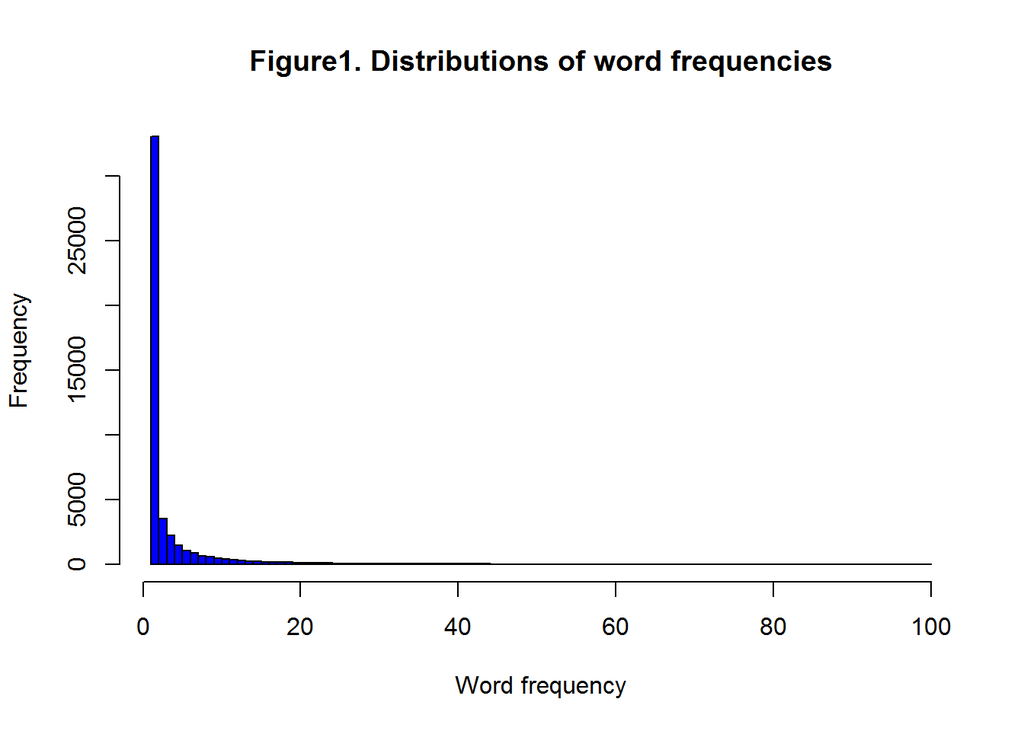

```r
#create DTM(document term matrix) limit the words lengths to 2 to 20
dtm <-DocumentTermMatrix(corpus, control=list(wordLengths=c(2, 20)))
#get the frequency of occurrence of each word in the corpus, we simply sum over all rows to give column sums
freq<-colSums(as.matrix(dtm))
freq_data<-subset(data.frame(freq),freq <=100)
hist(freq_data$freq,breaks=100,col="blue",main="Figure1. Distributions of word frequencies",xlab="Word frequency")
```

From figure1 we can see that most of the words happened once and very few words repeated more than 20 times.

### How many unique words do you need in a frequency sorted dictionary to cover 50% of all word instances in the language? 90%?

```r
#order the data based on frequency
freq_data<-as.data.frame(freq)
freq_data$words<-names(freq_data)
freq_data2<-freq_data[order(freq),]
#get the row number when sum of the frequncies above the row cover 50% of all word freq
sum<-0
for(i in 1:length(freq_data2$freq)){
        sum<-sum+freq_data2$freq[i]
        if (sum>=0.5*sum(freq_data2$freq)) {
                break
                }
}
print("cover 50%")
```

```
## [1] "cover 50%"
```

```r
print(i)
```

```
## [1] 49099
```

```r
#get the row number when sum of the frequncies above the row cover 90% of all word freq
sum<-0
for(i in 1:length(freq_data2$freq)){
        sum<-sum+freq_data2$freq[i]
        if (sum>=0.9*sum(freq_data2$freq)) {
                break
        }
}
print("cover 90%")
```

```
## [1] "cover 90%"
```

```r
print(i)
```

```
## [1] 50114
```

```r
print("Total words")
```

```
## [1] "Total words"
```

```r
sum(freq_data2$freq)
```

```
## [1] 464763
```

“an n-gram of size 1 is referred to as a”unigram“; size 2 is a”bigram" (or, less commonly, a “digram”); size 3 is a “trigram”. English cardinal numbers are sometimes used, e.g., “four-gram”, “five-gram”, and so on“” from:https://en.wikipedia.org/wiki/N-gram

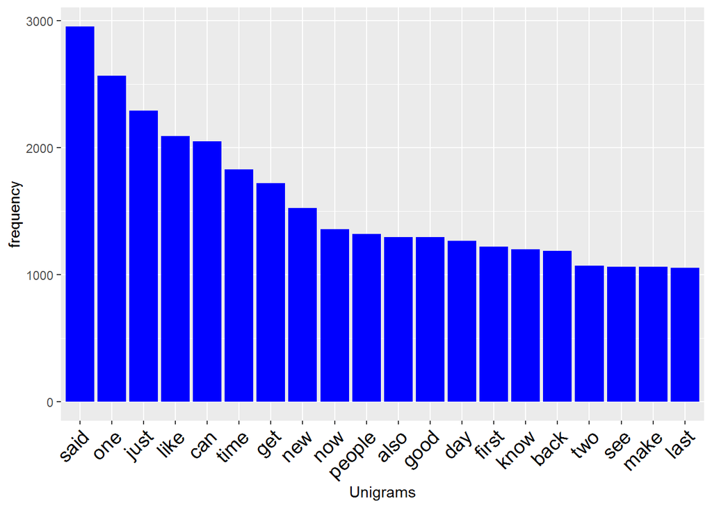

```r
UnigramTokenizer <-
        function(x)
                unlist(lapply(ngrams(words(x), 1), paste, collapse = " "), use.names = FALSE)
BigramTokenizer <-
        function(x)
                unlist(lapply(ngrams(words(x), 2), paste, collapse = " "), use.names = FALSE)
TrigramTokenizer <-
        function(x)
                unlist(lapply(ngrams(words(x), 3), paste, collapse = " "), use.names = FALSE)

Unigram_tdm <- TermDocumentMatrix(corpus, control = list(tokenize = UnigramTokenizer))
Bigram_tdm <- TermDocumentMatrix(corpus, control = list(tokenize = BigramTokenizer))
Trigram_tdm <- TermDocumentMatrix(corpus, control = list(tokenize = TrigramTokenizer))

uni <- findFreqTerms(Unigram_tdm,lowfreq = 50)
bi <- findFreqTerms(Bigram_tdm,lowfreq = 20)
tri <- findFreqTerms(Trigram_tdm,lowfreq = 10)

unifreq <- rowSums(as.matrix(Unigram_tdm[uni,]))
Unigram_data <- data.frame(word=names(unifreq),frequency=unifreq)
Unigram_data2<-Unigram_data[with(Unigram_data,order(-frequency)), ]
Unigram_data2<-data.frame(head(Unigram_data2,20))

bifreq <- rowSums(as.matrix(Bigram_tdm[bi,]))
Bigram_data <- data.frame(word=names(bifreq),frequency=bifreq)
Bigram_data2<-Bigram_data[with(Bigram_data,order(-frequency)), ]
Bigram_data2<-data.frame(head(Bigram_data2,20))

trifreq <- rowSums(as.matrix(Trigram_tdm[tri,]))
Trigram_data <- data.frame(word=names(trifreq),frequency=trifreq)
Trigram_data2<-Trigram_data[with(Trigram_data,order(-frequency)), ]
Trigram_data2<-data.frame(head(Trigram_data2,20))


library(ggplot2)
p1<-ggplot(data=Unigram_data2)+
        aes(x=reorder(word,-frequency),y=frequency)+
        geom_bar(stat="identity",fill="blue")+
        theme(axis.text.x = element_text(color="black", size=14, angle=45,hjust=1))+
        xlab("Unigrams")
p1
```

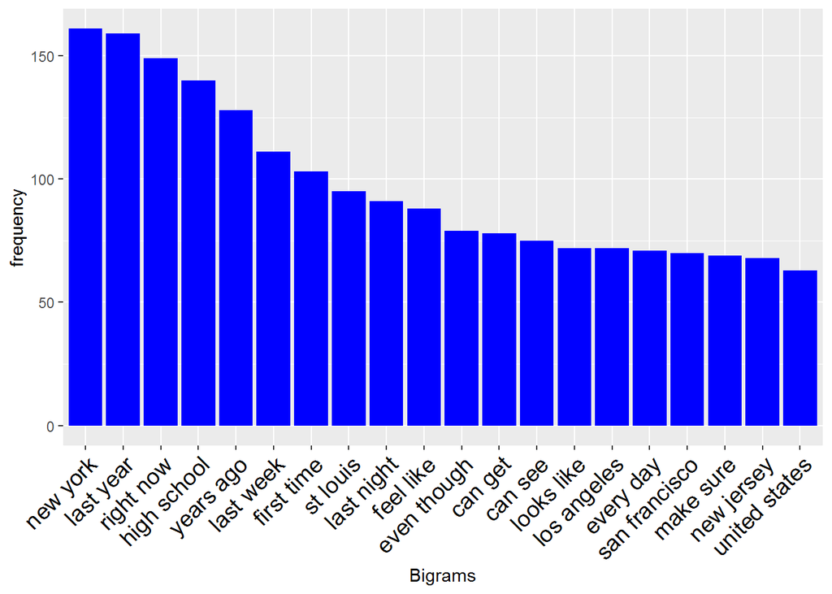

```r
p2<-ggplot(data=Bigram_data2)+
        aes(x=reorder(word,-frequency),y=frequency)+
        geom_bar(stat="identity",fill="blue")+
        theme(axis.text.x = element_text(color="black", size=14, angle=45,hjust=1))+
        xlab("Bigrams")
p2
```

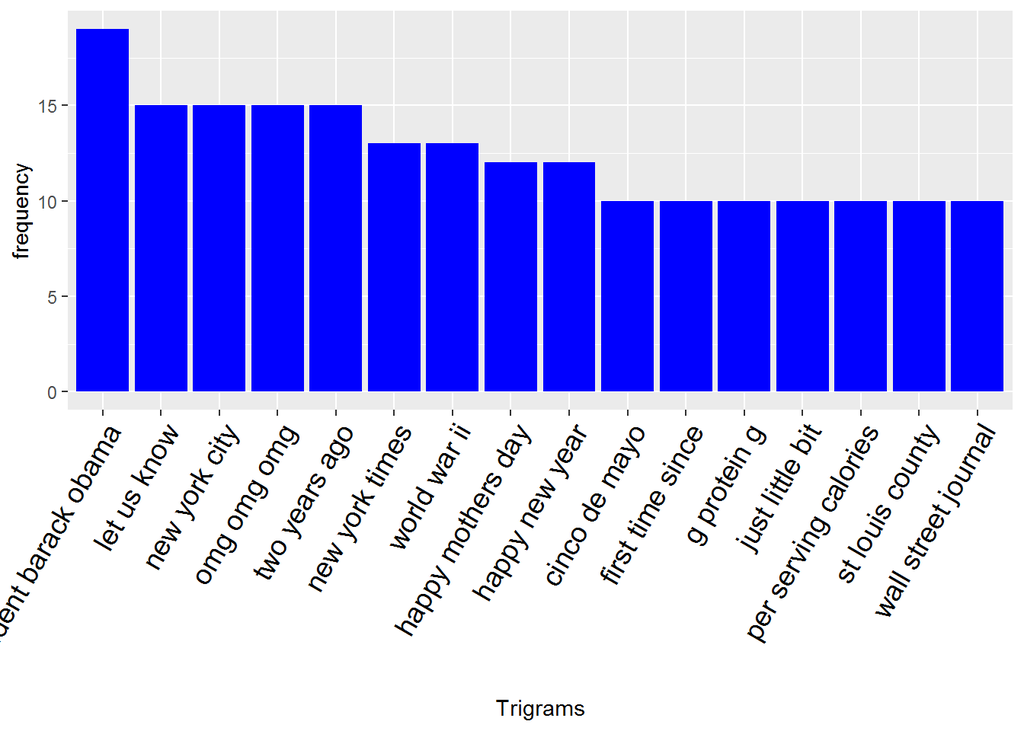

```r
p3<-ggplot(data=Trigram_data2)+
        aes(x=reorder(word,-frequency),y=frequency)+
        geom_bar(stat="identity",fill="blue")+
        theme(axis.text.x = element_text(color="black", size=14, angle=60,hjust=1))+
        xlab("Trigrams")
p3
```

*Method was adopted from http://tm.r-forge.r-project.org/faq.html

### Plan for creating a prediction algorithm and Shiny app

In order to make the Shiny app for words prediction. In the next step I will use all the contents of the three text file: blogs, news, and twitter and clean the data the same way used in this report. n-gram model will be used for prediction of the next word based on previous 1, 2, or 3 words. For example, the app will give the top 3 most frequency next word based on the frequency rank in the bigram or trigram list.